# Project: Investigate a Dataset (TMDb Dataset)

- Introduction
- Data Wrangling
- Exploratory Data Analysis
- Conclusions

## Introduction

> The movies data set contains the records from the year 1960 to 2015 of movies budget, revenue, cast, production companies names,genres,etc. We can find many thinks from this dataset.

## Question to be Answer:

> - 1) High profit making Director and Movie from 1960 to 2015.
> - 2) Low profit making Director and Movie from 1960 to 2015.
> - 3) Top 5 high profit making Director and Movie from 1960 to 2015.
> - 4) How year after year earning of Moives increases.
> - 5) Top 10 Production Companies based upon how much movies that product.
> - 6) Top genres polular from 1960 to 2015.
> - 7) Number of Movies release year by year.
> - 8) Top 10 popular movies in 2015 based on Popularity.
> - 9) Average Runtime, Profit earned, Budget, Revenue for year 2015.
> - 10) Top 5 high profit making Director and Movie in the year 2015.

```python
# importing library.
import pandas as pd
import matplotlib.pyplot as plt

# This line is print the graph inside jupyter notebook.
%matplotlib inline
```

## Data Wrangling

### General Properties

```python
# Loading the tmdb-movies.csv file and storing in df var as DataFrame.
df = pd.read_csv('tmdb-movies.csv')
```

### Just View the Dataset.

```python
# Checking wether the data have load or not by head function.
df.head()
```

|  | id | imdb_id | popularity | budget | revenue | original_title | cast | homepage | director | tagline | ... | overview | runtime | genres | production_companies | release_date | vote_count | vote_average | release_year | budget_adj | revenue_adj |
| --- | --- | --- | --- | --- | --- | --- | --- | --- | --- | --- | --- | --- | --- | --- | --- | --- | --- | --- | --- | --- | --- |
| 0 | 135397 | tt0369610 | 32.985763 | 150000000 | 1513528810 | Jurassic World | Chris Pratt\|Bryce Dallas Howard\|Irrfan Khan\|Vi... | http://www.jurassicworld.com/ | Colin Trevorrow | The park is open. | ... | Twenty-two years after the events of Jurassic ... | 124 | Action\|Adventure\|Science Fiction\|Thriller | Universal Studios\|Amblin Entertainment\|Legenda... | 6/9/15 | 5562 | 6.5 | 2015 | 1.379999e+08 | 1.392446e+09 |
| 1 | 76341 | tt1392190 | 28.419936 | 150000000 | 378436354 | Mad Max: Fury Road | Tom Hardy\|Charlize Theron\|Hugh Keays-Byrne\|Nic... | http://www.madmaxmovie.com/ | George Miller | What a Lovely Day. | ... | An apocalyptic story set in the furthest reach... | 120 | Action\|Adventure\|Science Fiction\|Thriller | Village Roadshow Pictures\|Kennedy Miller Produ... | 5/13/15 | 6185 | 7.1 | 2015 | 1.379999e+08 | 3.481613e+08 |
| 2 | 262500 | tt2908446 | 13.112507 | 110000000 | 295238201 | Insurgent | Shailene Woodley\|Theo James\|Kate Winslet\|Ansel... | http://www.thedivergentseries.movie/#insurgent | Robert Schwentke | One Choice Can Destroy You | ... | Beatrice Prior must confront her inner demons ... | 119 | Adventure\|Science Fiction\|Thriller | Summit Entertainment\|Mandeville Films\|Red Wago... | 3/18/15 | 2480 | 6.3 | 2015 | 1.012000e+08 | 2.716190e+08 |
| 3 | 140607 | tt2488496 | 11.173104 | 200000000 | 2068178225 | Star Wars: The Force Awakens | Harrison Ford\|Mark Hamill\|Carrie Fisher\|Adam D... | http://www.starwars.com/films/star-wars-episod... | J.J. Abrams | Every generation has a story. | ... | Thirty years after defeating the Galactic Empi... | 136 | Action\|Adventure\|Science Fiction\|Fantasy | Lucasfilm\|Truenorth Productions\|Bad Robot | 12/15/15 | 5292 | 7.5 | 2015 | 1.839999e+08 | 1.902723e+09 |
| 4 | 168259 | tt2820852 | 9.335014 | 190000000 | 1506249360 | Furious 7 | Vin Diesel\|Paul Walker\|Jason Statham\|Michelle ... | http://www.furious7.com/ | James Wan | Vengeance Hits Home | ... | Deckard Shaw seeks revenge against Dominic Tor... | 137 | Action\|Crime\|Thriller | Universal Pictures\|Original Film\|Media Rights ... | 4/1/15 | 2947 | 7.3 | 2015 | 1.747999e+08 | 1.385749e+09 |

5 rows × 21 columns

### Data Cleaning.

- 1) Removing duplicates rows and empty rows.
- 2) Removing NAN values from genres and cast column.
- 3) Adding profit_earned column.

## 1) Removing duplicates rows and empty rows.

Checking for duplicates Rows in df.

```python
sum(df.duplicated())
```

```
1
```

Remove duplicates Rows in df.

```python
df.drop_duplicates(inplace=True)
```

## 2) Removing NAN values from genres and cast column.

Checking for NAN values from df.

```python
df.isnull().sum()
```

```
id                         0
imdb_id                   10
popularity                 0
budget                     0
revenue                    0
original_title             0
cast                      76
homepage                7929
director                  44
tagline                 2824
keywords                1493
overview                   4
runtime                    0
genres                    23
production_companies    1030
release_date               0
vote_count                 0
vote_average               0
release_year               0
budget_adj                 0
revenue_adj                0
dtype: int64
```

Removing NAN from genres and cast column in df.

```python
df.dropna(subset = ['genres'],inplace=True)
df.dropna(subset =['cast'], inplace=True)
```

```python
df.isnull().sum()
```

```
id                         0
imdb_id                    8
popularity                 0
budget                     0
revenue                    0
original_title             0
cast                       0
homepage                7864
director                  36
tagline                 2757
keywords                1445
overview                   3
runtime                    0
genres                     0
production_companies     976
release_date               0
vote_count                 0
vote_average               0
release_year               0
budget_adj                 0
revenue_adj                0
dtype: int64
```

```python
# Clecking the column datatype.
df.info()
```

```
<class 'pandas.core.frame.DataFrame'>
Int64Index: 10767 entries, 0 to 10865
Data columns (total 21 columns):
id                      10767 non-null int64
imdb_id                 10759 non-null object
popularity              10767 non-null float64
budget                  10767 non-null int64
revenue                 10767 non-null int64
original_title          10767 non-null object
cast                    10767 non-null object
homepage                2903 non-null object
director                10731 non-null object
tagline                 8010 non-null object
keywords                9322 non-null object
overview                10764 non-null object
runtime                 10767 non-null int64
genres                  10767 non-null object
production_companies    9791 non-null object
release_date            10767 non-null object
vote_count              10767 non-null int64
vote_average            10767 non-null float64
release_year            10767 non-null int64
budget_adj              10767 non-null float64
revenue_adj             10767 non-null float64
dtypes: float64(4), int64(6), object(11)
memory usage: 1.4+ MB
```

## 3) Adding profit_earned column.

```python
# Adding new Column profit_earned by subtracting revenue by budget column using insert function.
# New column added 5 index after revenue column.
df.insert(5,'profit_earned',df['revenue']-df['budget'])
```

```python
# Checking for head() or data change.
df.head()
```

|  | id | imdb_id | popularity | budget | revenue | profit_earned | original_title | cast | homepage | director | ... | overview | runtime | genres | production_companies | release_date | vote_count | vote_average | release_year | budget_adj | revenue_adj |
| --- | --- | --- | --- | --- | --- | --- | --- | --- | --- | --- | --- | --- | --- | --- | --- | --- | --- | --- | --- | --- | --- |
| 0 | 135397 | tt0369610 | 32.985763 | 150000000 | 1513528810 | 1363528810 | Jurassic World | Chris Pratt\|Bryce Dallas Howard\|Irrfan Khan\|Vi... | http://www.jurassicworld.com/ | Colin Trevorrow | ... | Twenty-two years after the events of Jurassic ... | 124 | Action\|Adventure\|Science Fiction\|Thriller | Universal Studios\|Amblin Entertainment\|Legenda... | 6/9/15 | 5562 | 6.5 | 2015 | 1.379999e+08 | 1.392446e+09 |
| 1 | 76341 | tt1392190 | 28.419936 | 150000000 | 378436354 | 228436354 | Mad Max: Fury Road | Tom Hardy\|Charlize Theron\|Hugh Keays-Byrne\|Nic... | http://www.madmaxmovie.com/ | George Miller | ... | An apocalyptic story set in the furthest reach... | 120 | Action\|Adventure\|Science Fiction\|Thriller | Village Roadshow Pictures\|Kennedy Miller Produ... | 5/13/15 | 6185 | 7.1 | 2015 | 1.379999e+08 | 3.481613e+08 |
| 2 | 262500 | tt2908446 | 13.112507 | 110000000 | 295238201 | 185238201 | Insurgent | Shailene Woodley\|Theo James\|Kate Winslet\|Ansel... | http://www.thedivergentseries.movie/#insurgent | Robert Schwentke | ... | Beatrice Prior must confront her inner demons ... | 119 | Adventure\|Science Fiction\|Thriller | Summit Entertainment\|Mandeville Films\|Red Wago... | 3/18/15 | 2480 | 6.3 | 2015 | 1.012000e+08 | 2.716190e+08 |
| 3 | 140607 | tt2488496 | 11.173104 | 200000000 | 2068178225 | 1868178225 | Star Wars: The Force Awakens | Harrison Ford\|Mark Hamill\|Carrie Fisher\|Adam D... | http://www.starwars.com/films/star-wars-episod... | J.J. Abrams | ... | Thirty years after defeating the Galactic Empi... | 136 | Action\|Adventure\|Science Fiction\|Fantasy | Lucasfilm\|Truenorth Productions\|Bad Robot | 12/15/15 | 5292 | 7.5 | 2015 | 1.839999e+08 | 1.902723e+09 |
| 4 | 168259 | tt2820852 | 9.335014 | 190000000 | 1506249360 | 1316249360 | Furious 7 | Vin Diesel\|Paul Walker\|Jason Statham\|Michelle ... | http://www.furious7.com/ | James Wan | ... | Deckard Shaw seeks revenge against Dominic Tor... | 137 | Action\|Crime\|Thriller | Universal Pictures\|Original Film\|Media Rights ... | 4/1/15 | 2947 | 7.3 | 2015 | 1.747999e+08 | 1.385749e+09 |

5 rows × 22 columns

## Exploratory Data Analysis

### 1) High profit making Director and Movie from 1960 to 2015.

```python
# Getting max position from profit_earned column and Getting data from
# 'director','profit_earned','original_title' column.
df.loc[df['profit_earned'].idxmax(),['director','profit_earned','original_title']]
```

```
director          James Cameron
profit_earned        2544505847
original_title           Avatar
Name: 1386, dtype: object
```

### 2) Low profit making Director and Movie from 1960 to 2015.

```python
# Getting min position from profit_earned column and Getting data from
# 'director','profit_earned','original_title' column.
df.loc[df['profit_earned'].idxmin(),['director','profit_earned','original_title']]
```

```
director                 Sngmoo Lee
profit_earned            -413912431
original_title    The Warrior's Way
Name: 2244, dtype: object
```

### 3) Top 5 high profit making Director and Movie from 1960 to 2015.

```python
# Sort values from profit_earned column and not sort by ascending order
# it means larger values comes first and store in sort var.
# it return the dataframe of sorted values.
sort = df.sort_values('profit_earned',ascending = False)
```

```python
# Here we are getting top 5 sorted data from 'profit_earned','director','original_title','genres'
# columns.
sort.loc[:,['profit_earned','director','original_title','genres']].head(5)
```

|  | profit_earned | director | original_title | genres |
| --- | --- | --- | --- | --- |
| 1386 | 2544505847 | James Cameron | Avatar | Action\|Adventure\|Fantasy\|Science Fiction |
| 3 | 1868178225 | J.J. Abrams | Star Wars: The Force Awakens | Action\|Adventure\|Science Fiction\|Fantasy |
| 5231 | 1645034188 | James Cameron | Titanic | Drama\|Romance\|Thriller |
| 0 | 1363528810 | Colin Trevorrow | Jurassic World | Action\|Adventure\|Science Fiction\|Thriller |
| 4 | 1316249360 | James Wan | Furious 7 | Action\|Crime\|Thriller |

[figure not shown]

```python
# Here we are grouping by release_year column and count the movies release by year
# and get profit_earned column and plot it in graph.
plot = df.groupby('release_year').count()['profit_earned'].plot()
# Set the title Profit Earned.
plt.title('Profit Earned.')

# set x label to Release Year.
plot.set_xlabel('Release Year.')

# set y label to Rate of Price.
plot.set_ylabel('Profit Earned by Movies.')

# Adjust the graph.
plt.tight_layout()
```

### 5) Top 10 Production Companies based upon how much movies that product.

```python
# Count the values from production_companies column and get top 10 head.
df['production_companies'].value_counts().head(10)
```

```
Paramount Pictures                        156
Universal Pictures                        133
Warner Bros.                               84
Walt Disney Pictures                       75
Columbia Pictures                          72
Metro-Goldwyn-Mayer (MGM)                  72
New Line Cinema                            61
Touchstone Pictures                        51
20th Century Fox                           50
Twentieth Century Fox Film Corporation     49
Name: production_companies, dtype: int64
```

### 6) Top genres polular from 1960 to 2015.

```python
# This Function return the count of genres.
def genres_split(column):
    #will take a column, and separate the string by '|' store in get_string var datatype is string.
    get_string = df[column].str.cat(sep = '|')

    #We convert get_string (Datatype:= string) into pandas series and every word is split by '|' and  store in series var.
    series = pd.Series(get_string.split('|'))

    #We count the values and arranging in descending order store in count var.
    count = series.value_counts(ascending = False)

    return count
```

```python
# storing count of genres in count var.
count = genres_split('genres')
```

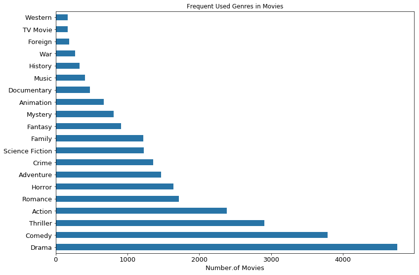

```python
#ploting
data_plot = count.plot.barh(color = '#2874A6', fontsize = 13)

#title
data_plot.set(title = 'Frequent Used Genres in Movies')

# on x axis
data_plot.set_xlabel('Number.of Movies', color = 'black', fontsize = '13')

#figure size(width, height)
data_plot.figure.set_size_inches(13, 9)

#ploting the graph
plt.show()
```

```python
# Count values from release_year column get top 16 by using head function store in movies_release var.
movies_release = df['release_year'].value_counts().head(16)
```

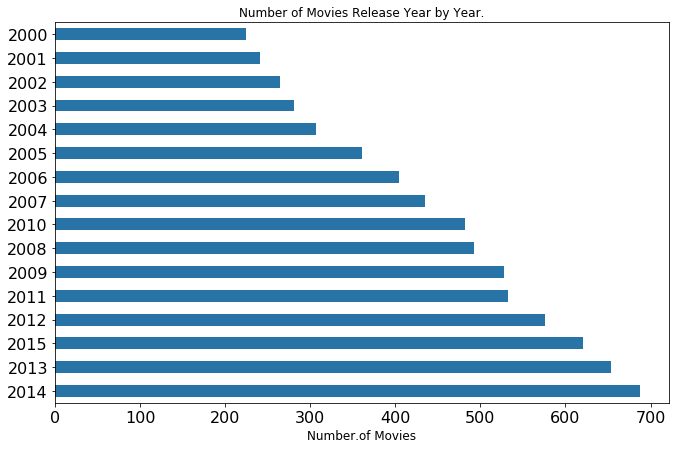

```python
#ploting
data_plot = movies_release.plot.barh(color = '#2874A6', fontsize = 16)

#title
data_plot.set(title = 'Number of Movies Release Year by Year.')

# on x axis
data_plot.set_xlabel('Number.of Movies', color = 'black', fontsize = '12')

#figure size(width, height)
data_plot.figure.set_size_inches(11, 7)

#ploting the graph
plt.show()
```

### 8) Top 10 popular movies in 2015 based on Popularity.

```python
# Getting all movies records of 2015 store in movies_2015 var and it is DataFrame.
movies_2015 = df[df['release_year'] == 2015]
```

```python
# Sort the movies of 2015 from popularity column in non ascending order store in most_popular var it datatype is DataFrame.
most_popular = movies_2015.sort_values('popularity' ,ascending = False)
```

```python
# Get Top 10 polular movies list.Getting data from original_title and genres column.
most_popular.loc[:,['original_title','genres']].head(10)
```

|  | original_title | genres |
| --- | --- | --- |
| 0 | Jurassic World | Action\|Adventure\|Science Fiction\|Thriller |
| 1 | Mad Max: Fury Road | Action\|Adventure\|Science Fiction\|Thriller |
| 2 | Insurgent | Adventure\|Science Fiction\|Thriller |
| 3 | Star Wars: The Force Awakens | Action\|Adventure\|Science Fiction\|Fantasy |
| 4 | Furious 7 | Action\|Crime\|Thriller |
| 5 | The Revenant | Western\|Drama\|Adventure\|Thriller |
| 6 | Terminator Genisys | Science Fiction\|Action\|Thriller\|Adventure |
| 7 | The Martian | Drama\|Adventure\|Science Fiction |
| 8 | Minions | Family\|Animation\|Adventure\|Comedy |
| 9 | Inside Out | Comedy\|Animation\|Family |

### 9) Average Runtime, Profit earned, Budget, Revenue for year 2015.

```python
# This function to calculate the average for 2015 movies.
def average(column):
    return movies_2015[column].mean()
```

#### Average Runtime for year 2015.

```python
average('runtime')
```

```
96.61612903225806
```

#### Average Profit earned for year 2015.

```python
average('profit_earned')
```

```
30912746.711290322
```

#### Average Budget for year 2015.

```python
average('budget')
```

```
12252496.05967742
```

#### Average Revenue for year 2015.

```python
average('revenue')
```

```
43165242.770967744
```

### 10) Top 5 high profit making Director and Movie in the year 2015.

```python
# Sorting values from profit_earned column but not in ascending order.
# And getting data from 'profit_earned','director','original_title','genres' columns.
# printing top 5 movies by using head function.
movies_2015.sort_values('profit_earned',ascending = False).loc[:,['profit_earned','director','original_title','genres']].head()
```

|  | profit_earned | director | original_title | genres |
| --- | --- | --- | --- | --- |
| 3 | 1868178225 | J.J. Abrams | Star Wars: The Force Awakens | Action\|Adventure\|Science Fiction\|Fantasy |
| 0 | 1363528810 | Colin Trevorrow | Jurassic World | Action\|Adventure\|Science Fiction\|Thriller |
| 4 | 1316249360 | James Wan | Furious 7 | Action\|Crime\|Thriller |
| 14 | 1125035767 | Joss Whedon | Avengers: Age of Ultron | Action\|Adventure\|Science Fiction |
| 8 | 1082730962 | Kyle Balda\|Pierre Coffin | Minions | Family\|Animation\|Adventure\|Comedy |

## Limitations : -

- The limitation of this dataset is that it has some missing values or nan values.
- There are also 0s in budget and revenue columns which are also consider as missing values.
- The missing values effect the results in data analysis because we have remove missing values for data analysis.
- This data set is from long period which in this case affect the revenue and budget of the movie data.
- This analysis might not be completely error free.
- We are not sure if the data provided to us is completely correct and up-to-date.